# Predictions on Trail Running Activities using Temporal Fusion Transformers

## Eric Aguayo

## The problem and its importance

- **Trail running** represents a complex endurance sport. Runner's performance depends on
  - Physiological responses.
  - Environmental conditions.
  - Terrain characteristics and elevation profiles.
- The ability to predict completion times and physiological responses allows better
  - Race strategy planning
    - Energy expediture management (How much perceived effort)
    - Pacing strategy (How fast to go)
    - Provisioning strategy (How much to carry between PCs)
  - Athlete safety monitoring
  - Training optimization

## The dataset

- The dataset consists of trail running sessions from a Polar Vantage V watch
- Filtered training sessions from 2020
- Filtered for long endurance activities (3-6 hours duration)
- Filtered activites corresponding to trail running sport

```
{
  // ... more fields ...
  "physicalInformationSnapshot": {
    "dateTime": "2025-02-13T16:48:40.000",
    "sex": "MALE",
    // ... more fields
  },
  "exercises": [
    {
      "sport": "TRAIL_RUNNING",
      // ... more fields ...
      "samples": {
        "altitude": [
            {
                "dateTime": "2022-12-27T07:23:33.486",
                "value": 2651.487
            },
            {
                "dateTime": "2022-12-27T07:23:34.486",
                "value": 2651.487
            },
            // ... more fields ...
        ],
        "heartRate": {
            {
                "dateTime": "2022-12-27T07:23:33.486",
                "value": 139
            },
            {
                "dateTime": "2022-12-27T07:23:34.486",
                "value": 142
            },
            // ... more fields ...
        },
        // ... more fields ...
      }
      // ... more fields ...
    }
  ]
}
```

## Data preprocessing

- Each session was provided in a JSON file then processesed and converted into a pandas DataFrame, then exported to a CSV files
- Resampled at 2-meter distance intervals to enable distance-based temporal predictions.
- Features were engineered to include `elevation_gain`, `elevation_loss`, `elevation_diff`.
- Session identifiers were encoded for use as categorical variables (`session_id`, `session_id_encoded`)
- A new sequential index `time_idx` was generated, necessary for compatibility with the `pytorch forecasting` library

| distance | timestamp | heartRate | duration | altitude | distance_diff | temperature | cadence | speed | elevation_diff | elevation_gain | elevation_loss | session_id | time_idx | session_id_encoded |
| --- | --- | --- | --- | --- | --- | --- | --- | --- | --- | --- | --- | --- | --- | --- |
| 0.0 | 2021-03-13 06:10:55.983000000 | 75.0 | 0.0 | 2915.143 | 0.0 | 21.2 | 0.0 | 0.0 | 0.0 | 0.0 | 0.0 | training-session-2021-03... | 0 | 5782963264 |
| 2.0 | 2021-03-13 06:10:56.896043520 | 75.89 | 0.91 | 2915.35 | 2.0 | 21.17 | 1.78 | 0.20 | 0.20 | 0.20 | 0.0 | training-session-2021-03... | 1 | 5782963264 |
| 4.0 | 2021-03-13 06:10:57.809086976 | 76.78 | 1.83 | 2915.55 | 2.0 | 21.14 | 3.57 | 0.39 | 0.20 | 0.41 | 0.0 | training-session-2021-03... | 2 | 5782963264 |
| 6.0 | 2021-03-13 06:10:58.722130432 | 77.67 | 2.74 | 2915.76 | 2.0 | 21.12 | 5.35 | 0.59 | 0.20 | 0.61 | 0.0 | training-session-2021-03... | 3 | 5782963264 |
| 8.0 | 2021-03-13 06:10:59.635173888 | 78.57 | 3.65 | 2915.96 | 2.0 | 21.09 | 7.13 | 0.79 | 0.20 | 0.82 | 0.0 | training-session-2021-03... | 4 | 5782963264 |

```python
# Import requiered libraries
import pandas as pd
import matplotlib.pyplot as plt
import os
import random

# Define the directory containing the processed data
data_dir = "./data/resampled"
# Get the training files list
training_files=os.listdir(data_dir)

# Get the files count
print(f"Number of training files: {len(training_files)}")
```

```
Number of training files: 106
```

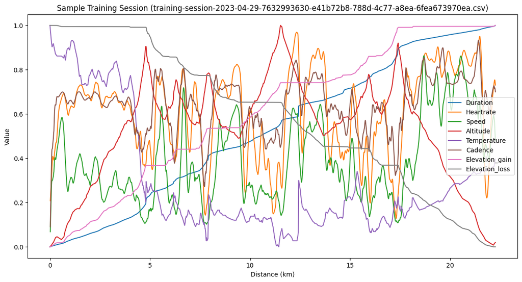

```python
plot_random_sample()
```

## DataModule

- `TFTDataModule` class
  - Implemented using PyTorch Lightning's `LightningDataModule` and the `TimeSeriesDataSet` class from the `pytorch forecasting` library
  - Designed to work with time series models.
  - Session identifiers (`session_id`) were used as categorical variables.

### Data Splitting

- Initial approach: temporal splits (standard recommendation for working with time series to prevent data leakage).
- Not applicable in this case because
  - We are aiming for cold-start predictions where the runner has not initiated yet the activity
  - Each session can be assumed to be independent
- Changed the approach to split by sessions

```python
from lib.data import TFTDataModule

# Create and setup the TFT data module
data_module = TFTDataModule(
    data_dir="./data/resampled",
    min_encoder_length=40,
    max_encoder_length=200,
    max_prediction_length=20,    # Predict next 20 distance steps
    batch_size=64,
)
data_module.setup()
```

```
Loading 106 training session files...
```

```
Loaded 106 sessions with 1164615 total data points
Minimum required sequence length: 220
Valid sessions (sufficient length): 106/106
Session-based splits for cold-start evaluation:
Train sessions: 79, Val sessions: 15, Test sessions: 12
Train data points: 869193, Val: 180016, Test: 115406
Overlap between train-val: 0, train-test: 0
Training samples: 877172
Validation samples: 181531
Test samples: 12
Training samples: 877172
Validation samples: 181531
Test samples: 12
```

## The model

**Temporal Fusion Transformer (TFT)**: A deep learning model specifically designed for time series prediction that can handle both static variables, known variables in the future, and unknown variables in the future.

`TrailRunningTFT` class:

- Initial approach: Initialized `TemporalFusionTransformer` class from `pytorch-forecasting` from the class.
- Class `TemporalFusionTransformer` is already a *Pytorch Lightning* module.
- Cleaner code just by extending it and allowing Lightning handle the steps through it.

## Arquitectura

[figure not shown]

**Model Features:**

- **Architecture**: Temporal Fusion Transformer optimized for time series (sequential)
- **Future Known Variables**: `altitude`, `elevation_diff`, `elevation_gain`, `elevation_loss`, `distance_diff` (available at prediction time)
- **Future Unknown Variables**: `duration`, `heartRate`, `temperature`, `cadence`, `speed` (needs to be predicted)
- **Target Variable**: `duration`, `heartRate`, `temperature`, `cadence`, `speed`
- **Sequence Length (Encoder)**: 40-200 input time steps
- **Prediction Horizon**: 20 steps into the future

```
   | Name                               | Type                            | Params | Mode
------------------------------------------------------------------------------------------------
0  | loss                               | MultiLoss                       | 0      | train
1  | logging_metrics                    | ModuleList                      | 0      | train
2  | input_embeddings                   | MultiEmbedding                  | 0      | train
3  | prescalers                         | ModuleDict                      | 1.3 K  | train
4  | static_variable_selection          | VariableSelectionNetwork        | 78.3 K | train
5  | encoder_variable_selection         | VariableSelectionNetwork        | 71.4 K | train
6  | decoder_variable_selection         | VariableSelectionNetwork        | 34.8 K | train
7  | static_context_variable_selection  | GatedResidualNetwork            | 16.8 K | train
8  | static_context_initial_hidden_lstm | GatedResidualNetwork            | 16.8 K | train
9  | static_context_initial_cell_lstm   | GatedResidualNetwork            | 16.8 K | train
10 | static_context_enrichment          | GatedResidualNetwork            | 16.8 K | train
11 | lstm_encoder                       | LSTM                            | 33.3 K | train
12 | lstm_decoder                       | LSTM                            | 33.3 K | train
13 | post_lstm_gate_encoder             | GatedLinearUnit                 | 8.3 K  | train
14 | post_lstm_add_norm_encoder         | AddNorm                         | 128    | train
15 | static_enrichment                  | GatedResidualNetwork            | 20.9 K | train
16 | multihead_attn                     | InterpretableMultiHeadAttention | 10.4 K | train
17 | post_attn_gate_norm                | GateAddNorm                     | 8.4 K  | train
18 | pos_wise_ff                        | GatedResidualNetwork            | 16.8 K | train
19 | pre_output_gate_norm               | GateAddNorm                     | 8.4 K  | train
20 | output_layer                       | ModuleList                      | 325    | train
------------------------------------------------------------------------------------------------
```

## Training

Implemented in a separate python script `training.py`. Has several advantages:

- Use distributed processing to speed up training.
- Faster since it uses native python kernel instead of interactive python kernel that is adapted for notebooks and tend to be slower.
- Easier to duplicate and replicate different cases.
- Can be kept running in background without needing to keep active notebook session (unless the docker container crashes)

### Training Setup

```
    # ...
    min_encoder_length=40,
    max_encoder_length=200,
    max_prediction_length=20,
    batch_size=64, # Was increased from 32 to 64 to give more context during training
    hidden_size=64
    # ...
    max_epochs=30,
    accelerator='auto',
    strategy='ddp',
    devices=2,
    gradient_clip_val=0.1,
    enable_checkpointing=True,
    precision="32-true",
    callbacks=[
        early_stopping_callback,
        learning_rate_callback,
        checkpoint_callback,
    ]
    # ...
```

[figure not shown]

# Overfitting Analysis

## Possible causes

- Insuficient data features
  - Pre-session conditions (fatigue/Training Readiness)
  - Lack of inter-training relevant data (hydration/feeding)
  - Terrain conditions data (grass, mud, rock, ...)
  - Session type (training, competition)
- Insufficient data samples compared to model complexity
- Lack of enough regularization
- Model misconfiguration

## Changes that seemed to have significant impact

- Feature weighted loss function (80% to duration and 20% distributed across the rest of the variables)
- Increased batch size from 32 to 64
- Increased regularization parameters, specially adding weight_decay and increasing dropout from 0.1 to 0.25/0.3
- Increased training split a little bit

## Changes that seemed to NOT cause significant impact

- Decreasing max prediction length
- Decreasing min and max encoding length
- Different model and training parameters
  - `learning_rate`
  - `attention_head_size`
  - `hidden_size`
  - `hidden_continuous_size`

**Note:** These may cause a significant impact in the long term but probably did not run long enough to notice

## Notable changes

1. Validation loss is lower than Training loss across the epochs.
- **Hypothesis 1:** Larger batches likely produce more stable gradient estimates during training but still with dropout/noise loss may not decrease as much. In validation, uses full batches but without dropout it is a bit more accurate and generate lower loss.
- **Hypothesis 2:** Validation set might be easier for the model to infer and maybe not very representative.
2. The model did not seem to improve or overfit through additional epochs
- **Hypothesis:** The model may have already reached the best state possible through some of the steps within the first epoch.

## Evaluation

```
┏━━━━━━━━━━━━━━━━━━━━━━━━━━━┳━━━━━━━━━━━━━━━━━━━━━━━━━━━┓
┃        Test metric        ┃       DataLoader 0        ┃
┡━━━━━━━━━━━━━━━━━━━━━━━━━━━╇━━━━━━━━━━━━━━━━━━━━━━━━━━━┩
│     cadence test_MAE      │    12.842412948608398     │
│     cadence test_RMSE     │    22.440698623657227     │
│    cadence test_SMAPE     │    0.25639182329177856    │
│     duration test_MAE     │     2341.35302734375      │
│    duration test_RMSE     │     3113.195556640625     │
│    duration test_SMAPE    │     0.167913019657135     │
│    heartRate test_MAE     │    15.889894485473633     │
│    heartRate test_RMSE    │     18.74398422241211     │
│   heartRate test_SMAPE    │    0.11758080869913101    │
│      speed test_MAE       │    3.3657469749450684     │
│      speed test_RMSE      │    4.1212873458862305     │
│     speed test_SMAPE      │    0.39543601870536804    │
│   temperature test_MAE    │     5.393565654754639     │
│   temperature test_RMSE   │     6.32625675201416      │
│  temperature test_SMAPE   │    0.31597036123275757    │
│         test_loss         │    0.1885993778705597     │
└───────────────────────────┴───────────────────────────┘
```

## Conclusions

- Time series data demand **careful preprocessing**: Alignment with domain semantics (e.g., distance-based sampling > time-based) is critical for meaningful learning.
- Leverage **pre-built architectures** wisely: Understand every hyperparameter (e.g., min_encoder_length, attention heads, dropout) — default settings rarely suit niche domains like trail running.
- **Start small**, optimize deliberately: Begin with few epochs and conservative hyperparameters to establish baselines; avoid premature complexity.
- Track & visualize **every** experiment: Log validation loss, metrics, and attention patterns per run — plots reveal overfitting, instability, or feature misalignment.
- Change **one thing at a time**: Even with long training times, systematic ablation ensures you know why performance changes — no black-box tuning.
- **Regularization is non-negotiable**: Dropout, weight decay, and early stopping are essential to prevent memorization on small, noisy physiological datasets.

## Recommendations and Next Steps

- Log validation metrics at regular intervals → Discard assumptions that the model learns from the first epoch; monitor convergence behavior.
- Set min_encoder_length=0 → Enables robust cold-start inference by allowing predictions even with minimal historical context.
- Predict duration differences, not absolute duration → Accumulate deltas over time for greater numerical stability and reduced error propagation.
- Evaluate resampling intervals (e.g., 2m vs. 5m) → Balance temporal resolution with computational efficiency — 5m may be sufficient for most trail terrain.
- Adopt K-Fold Cross-Validation → Replace single-session splits to ensure reliable hyperparameter selection across diverse runner profiles.
- Explore domain-specific data augmentation → Apply techniques like synthetic terrain perturbations, Gaussian noise on physiological signals, or DTW-based warping.
- Enrich input features → Integrate RPE (perceived exertion), hydration logs, accelerometer/gyroscope gait metrics, and barometric pressure.
- Initialize inference with baseline values → Provide sensible starting points (e.g., resting HR, initial speed) to stabilize early-time predictions.